# Mathematics for Data Science

## Computer Lab 4

The aim of this lab is to delve into using `numpy` for doing linear algebra, and to show some applications.

Let's start by solving a typical linear algebra problem. We want to solve: $$ \begin{align*} 2x + y - z &= 2\\ x + 3y +2z & = 1\\ x + y + z & = 2. \end{align*} $$

We can write this system in the compact matrix form $$ A\mathbf{x} = \mathbf{b}, $$ where $$ A = \begin{bmatrix} 2 & 1 & -1 \\ 1 & 3 & 2\\ 1 & 1 & 1 \end{bmatrix} $$

$$\mathbf{b} = \begin{bmatrix} 2\\ 1\\ 2 \end{bmatrix} $$

and $$ \mathbf{x} = \begin{bmatrix} x\\ y\\ z \end{bmatrix}$$

We can define $A$ and $\mathbf{b}$ in `numpy` as follows.

```python
import numpy as np

A = np.array([[2,1,-1], [1,3,2], [1,1,1]])
b = np.array([2,1,2])

print(A)
```

```
[[ 2  1 -1]
 [ 1  3  2]
 [ 1  1  1]]
```

$A$ is a *list of lists*, and wrapping `np.array()` around it and $\mathbf{b}$ allows us to use `numpy` functions on them. For example, find out the order $\mathbf{b}$ by appending `.shape` to the end of `b`:

```python
# Use .shape here
b.shape
```

```
(3,)
```

That means that `b` has 3 rows and one column -- by default `numpy` stores vectors as *column vectors* (not row vectors).

Find the shapes of the different vectors below.

```python
c = np.array([1,2,3])
d = np.array([[1,2,3]])
```

```python
# find the shapes here
c.shape
d.shape
```

```
(1, 3)
```

Notice the difference between how `numpy` defines column vectors ans row vectors?

Some exercises:

- Define the following matrices with `numpy`: $$ X = \begin{bmatrix} 1 & 6\\ 3 & -1 \end{bmatrix} \quad Y = \begin{bmatrix} 1 & 1 & 1\\ 1 & -2 & 0 \end{bmatrix} \quad Z = \begin{bmatrix} 2 & 3 & 1\\ 0 & 1 & -2 \end{bmatrix} $$
- Find (where possible, and look at what `numpy` gives you when not): $$ X + Y; \quad Y + Z; \quad Y - Z $$

```python
# Define matrices here
X = np.array([[1,6], [3,-1]])
Y = np.array([[1,1,1],[1,-2,0]])
Z = np.array([[2,3,1],[0,1,-2]])
print(Z)
```

```
[[ 2  3  1]
 [ 0  1 -2]]
```

```python
# + them up here
# a = X + Y  unable to do so
Addition = Y + Z
Minus = Y - Z
print(Addition)
print(Minus)
```

```
[[ 3  4  2]
 [ 1 -1 -2]]
[[-1 -2  0]
 [ 1 -3  2]]
```

`np.matmul` does [matrix multiplication](https://docs.scipy.org/doc/numpy/reference/generated/numpy.matmul.html#numpy.matmul), and `.T` takes the [matrix transpose](https://docs.scipy.org/doc/numpy/reference/generated/numpy.transpose.html). Look at the syntax, and then find (where possible, or look at the error message):

- $XY$
- $ZX$
- $Z^TX$
- Confirm that $\mathbf{x} = (2,-1,1)$ is a solution of $A\mathbf{x} = \mathbf{b}$ from the top of the page.

```python
first = np.matmul(X,Y)
print(first)
# second = np.matmul(Z,X) unable to do so as the order is different
third = np.matmul(Z.T,X)
print(third)
```

```
[[  7 -11   1]
 [  2   5   3]]
[[ 2 12]
 [ 6 17]
 [-5  8]]
```

```python
A_inv = np.linalg.inv(A)
x = np.matmul(A_inv, b)
print(x)
```

```
[ 2. -1.  1.]
```

## Linear Regression

We're gonna take what we've just learned and do some linear regression. Let's look at our data. We have some MDS grades for some mysterious students.

| Student | Hours Spend Studying | Test 1 Score | Number of Burritos Eaten in 2020 | Final MDS Grade |
| --- | --- | --- | --- | --- |
| Raymond | 100 | 99 | 2 | 98 |
| Tobin | 30 | 80 | 10 | 77 |
| Sophie | 50 | 75 | 5 | 85 |
| Samudra | 45 | 80 | 3 | 85 |
| Lewis | 2 | 60 | 1 | 40 |

Let's start by converting this into a design matrix and a response variable vector. If that sentence didn't make a lot of sense you should **check out the MyUni module about linear regression [here](https://myuni.adelaide.edu.au/courses/54098/pages/week-6-matrices-in-linear-regression?module_item_id=1960229)**.

```python
X = np.array([[1, 100, 99,2],
              [1, 30,80,10],
              [1, 50,75,5],
              [1, 45, 80, 3],
              [1, 2,60,1]])

y = np.array([98,77,85,85,40])
```

Why is there a column of 1's there? Have a think and write your answer here!

Now here comes the fun part! Let's fit the linear regression! Use our equation to find our regression coefficents $\hat{\beta}$. Try to do some Googling on your own to figure out how to *find the matrix inverse using numpy*.

$$\hat{\boldsymbol{\beta}}=\left(X^{T} X\right)^{-1} X^{T} \boldsymbol{y}$$

```python
Beta = np.matmul(np.matmul(np.linalg.inv(np.matmul(X.T,X)),X.T),y)
print(Beta)
```

```
[58.56887209  0.6776153  -0.28148265  2.34481575]
```

Once you've found it, print it out. There are out coefficents of the linear regression. They tell us what the relationships between our variable are!

## Real Linear Regression

In reality, we usual don't type our data into numpy arrays and calculate our regression coefficents by hand. We use a package. We normally start with a pandas dataframe, and put in into a statistics package. Here's an example.

```python
import pandas as pd
grades_df = pd.DataFrame([[ 'Raymond' , 100 , 99 , 2 , 98 ],
              [ 'Tobin' , 30 , 80 , 10 , 77 ],
              [ 'Sophie' , 50 , 75 , 5 , 85 ],
              [ 'Samudra', 45 ,  80 , 3 , 85],
              [ 'Lewis' , 2 , 60 , 1 , 40 ]],
              columns = ['Student' , 'Hours Spend Studying' , 'Test 1 Score' ,
                         'Number of Burritos Eaten in 2020' , 'Final MDS Grade'])

grades_df
```

|  | Student | Hours Spend Studying | Test 1 Score | Number of Burritos Eaten in 2020 | Final MDS Grade |
| --- | --- | --- | --- | --- | --- |
| 0 | Raymond | 100 | 99 | 2 | 98 |
| 1 | Tobin | 30 | 80 | 10 | 77 |
| 2 | Sophie | 50 | 75 | 5 | 85 |
| 3 | Samudra | 45 | 80 | 3 | 85 |
| 4 | Lewis | 2 | 60 | 1 | 40 |

```python
from statsmodels.api import OLS
X = grades_df[['Hours Spend Studying','Test 1 Score','Number of Burritos Eaten in 2020']]
X["intercept"]= 1
y = grades_df['Final MDS Grade']
linear_model = OLS(y, X).fit()
print(linear_model.summary())
print(X)
```

```
                            OLS Regression Results
==============================================================================
Dep. Variable:        Final MDS Grade   R-squared:                       0.898
Model:                            OLS   Adj. R-squared:                  0.592
Method:                 Least Squares   F-statistic:                     2.934
Date:                Thu, 10 Sep 2020   Prob (F-statistic):              0.400
Time:                        10:44:02   Log-Likelihood:                -16.288
No. Observations:                   5   AIC:                             40.58
Df Residuals:                       1   BIC:                             39.01
Df Model:                           3
Covariance Type:            nonrobust
====================================================================================================
                                       coef    std err          t      P>|t|      [0.025      0.975]
----------------------------------------------------------------------------------------------------
Hours Spend Studying                 0.6776      0.772      0.877      0.542      -9.136      10.492
Test 1 Score                        -0.2815      1.972     -0.143      0.910     -25.344      24.781
Number of Burritos Eaten in 2020     2.3448      2.606      0.900      0.534     -30.764      35.454
intercept                           58.5689    115.382      0.508      0.701   -1407.496    1524.634
==============================================================================
Omnibus:                          nan   Durbin-Watson:                   2.025
Prob(Omnibus):                    nan   Jarque-Bera (JB):                0.833
Skew:                           0.951   Prob(JB):                        0.659
Kurtosis:                       2.385   Cond. No.                     1.74e+03
==============================================================================

Warnings:
[1] Standard Errors assume that the covariance matrix of the errors is correctly specified.
[2] The condition number is large, 1.74e+03. This might indicate that there are
strong multicollinearity or other numerical problems.
   Hours Spend Studying  Test 1 Score  Number of Burritos Eaten in 2020  \
0                   100            99                                 2
1                    30            80                                10
2                    50            75                                 5
3                    45            80                                 3
4                     2            60                                 1

   intercept
0          1
1          1
2          1
3          1
4          1
```

We did it! (If you got an error saying that you don't have statsmodels package, just run `!pip install statsmodels` in a new code cell). Now I know that there is a lot of stuff that just printed out, but statistics is an important part of science. Have a read of some of the outputs and look at words you may or may not be familiar with. Once you're done that, you have an extra challenge:

[output not shown]

# Challenge

Let's take this to the next level. We're going to load in some data about rates of [car crashes](https://www.kaggle.com/fivethirtyeight/fivethirtyeight-bad-drivers-dataset). Load in the data below and fit a linear model the predict `total`. Read the earlier link to know what each variable means.

```python
import pandas as pd
car_crashes = pd.read_csv('https://raw.githubusercontent.com/mwaskom/seaborn-data/master/car_crashes.csv')
car_crashes
```

|  | total | speeding | alcohol | not_distracted | no_previous | ins_premium | ins_losses | abbrev |
| --- | --- | --- | --- | --- | --- | --- | --- | --- |
| 0 | 18.8 | 7.332 | 5.640 | 18.048 | 15.040 | 784.55 | 145.08 | AL |
| 1 | 18.1 | 7.421 | 4.525 | 16.290 | 17.014 | 1053.48 | 133.93 | AK |
| 2 | 18.6 | 6.510 | 5.208 | 15.624 | 17.856 | 899.47 | 110.35 | AZ |
| 3 | 22.4 | 4.032 | 5.824 | 21.056 | 21.280 | 827.34 | 142.39 | AR |
| 4 | 12.0 | 4.200 | 3.360 | 10.920 | 10.680 | 878.41 | 165.63 | CA |
| 5 | 13.6 | 5.032 | 3.808 | 10.744 | 12.920 | 835.50 | 139.91 | CO |
| 6 | 10.8 | 4.968 | 3.888 | 9.396 | 8.856 | 1068.73 | 167.02 | CT |
| 7 | 16.2 | 6.156 | 4.860 | 14.094 | 16.038 | 1137.87 | 151.48 | DE |
| 8 | 5.9 | 2.006 | 1.593 | 5.900 | 5.900 | 1273.89 | 136.05 | DC |
| 9 | 17.9 | 3.759 | 5.191 | 16.468 | 16.826 | 1160.13 | 144.18 | FL |
| 10 | 15.6 | 2.964 | 3.900 | 14.820 | 14.508 | 913.15 | 142.80 | GA |
| 11 | 17.5 | 9.450 | 7.175 | 14.350 | 15.225 | 861.18 | 120.92 | HI |
| 12 | 15.3 | 5.508 | 4.437 | 13.005 | 14.994 | 641.96 | 82.75 | ID |
| 13 | 12.8 | 4.608 | 4.352 | 12.032 | 12.288 | 803.11 | 139.15 | IL |
| 14 | 14.5 | 3.625 | 4.205 | 13.775 | 13.775 | 710.46 | 108.92 | IN |
| 15 | 15.7 | 2.669 | 3.925 | 15.229 | 13.659 | 649.06 | 114.47 | IA |
| 16 | 17.8 | 4.806 | 4.272 | 13.706 | 15.130 | 780.45 | 133.80 | KS |
| 17 | 21.4 | 4.066 | 4.922 | 16.692 | 16.264 | 872.51 | 137.13 | KY |
| 18 | 20.5 | 7.175 | 6.765 | 14.965 | 20.090 | 1281.55 | 194.78 | LA |
| 19 | 15.1 | 5.738 | 4.530 | 13.137 | 12.684 | 661.88 | 96.57 | ME |
| 20 | 12.5 | 4.250 | 4.000 | 8.875 | 12.375 | 1048.78 | 192.70 | MD |
| 21 | 8.2 | 1.886 | 2.870 | 7.134 | 6.560 | 1011.14 | 135.63 | MA |
| 22 | 14.1 | 3.384 | 3.948 | 13.395 | 10.857 | 1110.61 | 152.26 | MI |
| 23 | 9.6 | 2.208 | 2.784 | 8.448 | 8.448 | 777.18 | 133.35 | MN |
| 24 | 17.6 | 2.640 | 5.456 | 1.760 | 17.600 | 896.07 | 155.77 | MS |
| 25 | 16.1 | 6.923 | 5.474 | 14.812 | 13.524 | 790.32 | 144.45 | MO |
| 26 | 21.4 | 8.346 | 9.416 | 17.976 | 18.190 | 816.21 | 85.15 | MT |
| 27 | 14.9 | 1.937 | 5.215 | 13.857 | 13.410 | 732.28 | 114.82 | NE |
| 28 | 14.7 | 5.439 | 4.704 | 13.965 | 14.553 | 1029.87 | 138.71 | NV |
| 29 | 11.6 | 4.060 | 3.480 | 10.092 | 9.628 | 746.54 | 120.21 | NH |
| 30 | 11.2 | 1.792 | 3.136 | 9.632 | 8.736 | 1301.52 | 159.85 | NJ |
| 31 | 18.4 | 3.496 | 4.968 | 12.328 | 18.032 | 869.85 | 120.75 | NM |
| 32 | 12.3 | 3.936 | 3.567 | 10.824 | 9.840 | 1234.31 | 150.01 | NY |
| 33 | 16.8 | 6.552 | 5.208 | 15.792 | 13.608 | 708.24 | 127.82 | NC |
| 34 | 23.9 | 5.497 | 10.038 | 23.661 | 20.554 | 688.75 | 109.72 | ND |
| 35 | 14.1 | 3.948 | 4.794 | 13.959 | 11.562 | 697.73 | 133.52 | OH |
| 36 | 19.9 | 6.368 | 5.771 | 18.308 | 18.706 | 881.51 | 178.86 | OK |
| 37 | 12.8 | 4.224 | 3.328 | 8.576 | 11.520 | 804.71 | 104.61 | OR |
| 38 | 18.2 | 9.100 | 5.642 | 17.472 | 16.016 | 905.99 | 153.86 | PA |
| 39 | 11.1 | 3.774 | 4.218 | 10.212 | 8.769 | 1148.99 | 148.58 | RI |
| 40 | 23.9 | 9.082 | 9.799 | 22.944 | 19.359 | 858.97 | 116.29 | SC |
| 41 | 19.4 | 6.014 | 6.402 | 19.012 | 16.684 | 669.31 | 96.87 | SD |
| 42 | 19.5 | 4.095 | 5.655 | 15.990 | 15.795 | 767.91 | 155.57 | TN |
| 43 | 19.4 | 7.760 | 7.372 | 17.654 | 16.878 | 1004.75 | 156.83 | TX |
| 44 | 11.3 | 4.859 | 1.808 | 9.944 | 10.848 | 809.38 | 109.48 | UT |
| 45 | 13.6 | 4.080 | 4.080 | 13.056 | 12.920 | 716.20 | 109.61 | VT |
| 46 | 12.7 | 2.413 | 3.429 | 11.049 | 11.176 | 768.95 | 153.72 | VA |
| 47 | 10.6 | 4.452 | 3.498 | 8.692 | 9.116 | 890.03 | 111.62 | WA |
| 48 | 23.8 | 8.092 | 6.664 | 23.086 | 20.706 | 992.61 | 152.56 | WV |
| 49 | 13.8 | 4.968 | 4.554 | 5.382 | 11.592 | 670.31 | 106.62 | WI |
| 50 | 17.4 | 7.308 | 5.568 | 14.094 | 15.660 | 791.14 | 122.04 | WY |

```python
nRow, nCol = car_crashes.shape
print(f'There are {nRow} rows and {nCol} columns')
```

```
There are 51 rows and 8 columns
```

```python
from statsmodels.api import OLS
C = car_crashes[['speeding','alcohol','not_distracted','no_previous','ins_premium','ins_losses']]
D = car_crashes['total']
linear_model = OLS(D, C).fit()
print(linear_model.summary())
```

```
                                 OLS Regression Results
=======================================================================================
Dep. Variable:                  total   R-squared (uncentered):                   0.997
Model:                            OLS   Adj. R-squared (uncentered):              0.997
Method:                 Least Squares   F-statistic:                              2697.
Date:                Thu, 10 Sep 2020   Prob (F-statistic):                    8.37e-56
Time:                        10:31:51   Log-Likelihood:                         -64.603
No. Observations:                  51   AIC:                                      141.2
Df Residuals:                      45   BIC:                                      152.8
Df Model:                           6
Covariance Type:            nonrobust
==================================================================================
                     coef    std err          t      P>|t|      [0.025      0.975]
----------------------------------------------------------------------------------
speeding          -0.0227      0.088     -0.257      0.798      -0.200       0.155
alcohol            0.5001      0.140      3.575      0.001       0.218       0.782
not_distracted     0.1819      0.047      3.894      0.000       0.088       0.276
no_previous        0.7323      0.060     12.150      0.000       0.611       0.854
ins_premium       -0.0007      0.001     -0.806      0.424      -0.002       0.001
ins_losses         0.0099      0.006      1.558      0.126      -0.003       0.023
==============================================================================
Omnibus:                       16.655   Durbin-Watson:                   1.839
Prob(Omnibus):                  0.000   Jarque-Bera (JB):               23.838
Skew:                           1.080   Prob(JB):                     6.66e-06
Kurtosis:                       5.559   Cond. No.                     1.06e+03
==============================================================================

Warnings:
[1] Standard Errors assume that the covariance matrix of the errors is correctly specified.
[2] The condition number is large, 1.06e+03. This might indicate that there are
strong multicollinearity or other numerical problems.
```

```python
from statsmodels.api import OLS
C = car_crashes['alcohol']
D = car_crashes['total']
linear_model = OLS(D, C).fit()
print(linear_model.summary())
```

```
                                 OLS Regression Results
=======================================================================================
Dep. Variable:                  total   R-squared (uncentered):                   0.969
Model:                            OLS   Adj. R-squared (uncentered):              0.968
Method:                 Least Squares   F-statistic:                              1552.
Date:                Thu, 10 Sep 2020   Prob (F-statistic):                    2.58e-39
Time:                        10:31:51   Log-Likelihood:                         -126.33
No. Observations:                  51   AIC:                                      254.7
Df Residuals:                      50   BIC:                                      256.6
Df Model:                           1
Covariance Type:            nonrobust
==============================================================================
                 coef    std err          t      P>|t|      [0.025      0.975]
------------------------------------------------------------------------------
alcohol        3.1002      0.079     39.400      0.000       2.942       3.258
==============================================================================
Omnibus:                       13.579   Durbin-Watson:                   1.588
Prob(Omnibus):                  0.001   Jarque-Bera (JB):               15.442
Skew:                          -1.031   Prob(JB):                     0.000443
Kurtosis:                       4.735   Cond. No.                         1.00
==============================================================================

Warnings:
[1] Standard Errors assume that the covariance matrix of the errors is correctly specified.
```

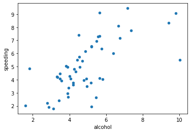

```python
car_crashes.plot.scatter(x = "alcohol", y = "speeding")
```

```python
# New datasets
chocolate = pd.read_csv('https://raw.githubusercontent.com/schloerke/cranvasOLD/master/files/data/chocolates.csv')
chocolate
```

|  | Name | MFR | Country | Type | Calories | CalFat | TotFat | SatFat | Chol | Na | Carbs | Fiber | Sugars | Protein |
| --- | --- | --- | --- | --- | --- | --- | --- | --- | --- | --- | --- | --- | --- | --- |
| 0 | Noir 86% Cacao | Cote D'Or | Belgium | Dark | 460.000000 | 380.000000 | 44.000000 | 26.000000 | 0.000000 | 0.000000 | 28.000000 | 10.000000 | 10.000000 | 8.000000 |
| 1 | 70% Cocoa | Cote D'Or | Belgium | Dark | 600.000000 | 432.000000 | 48.000000 | 30.000000 | 10.000000 | 0.000000 | 42.000000 | 10.000000 | 28.000000 | 8.000000 |
| 2 | Solid Dark Chocolate Bar | Godiva | Belgium | Dark | 534.883721 | 302.325581 | 32.558140 | 20.930233 | 0.000000 | 0.000000 | 60.465116 | 9.302326 | 46.511628 | 6.976744 |
| 3 | 72% Extra Dark Chocolate | Godiva | Belgium | Dark | 534.883721 | 348.837209 | 39.534884 | 20.930233 | 0.000000 | 81.395349 | 41.860465 | 13.953488 | 27.906977 | 9.302326 |
| 4 | Extra Dark Chocolate Bar | Guylian | Belgium | Dark | 575.757576 | 333.333333 | 39.393939 | 24.242424 | 0.000000 | 90.909091 | 48.484848 | 12.121212 | 33.333333 | 9.090909 |
| ... | ... | ... | ... | ... | ... | ... | ... | ... | ... | ... | ... | ... | ... | ... |
| 83 | Milk Chocolate Square | Ghiradelli | US | Milk | 475.000000 | 250.000000 | 27.500000 | 15.000000 | 12.500000 | 37.500000 | 62.500000 | 5.000000 | 52.500000 | 5.000000 |
| 84 | Symphony Milk Chocolate Bar | Hershey's | US | Milk | 530.952381 | 276.190476 | 30.476191 | 18.333333 | 23.809524 | 100.000000 | 58.095238 | 1.666667 | 54.047619 | 8.571429 |
| 85 | 35% Cacao Premium Milk | Hershey's | US | Milk | 550.000000 | 325.000000 | 37.500000 | 22.500000 | 25.000000 | 75.000000 | 52.500000 | 2.500000 | 50.000000 | 7.500000 |
| 86 | 41% Cacao Milk Chocolate | Scharffen Berger | US | Milk | 465.116279 | 302.325581 | 32.558140 | 20.930233 | 23.255814 | 116.279070 | 48.837209 | 4.651163 | 41.860465 | 7.233327 |
| 87 | Milk Chocolate | Trader Joe's | US | Milk | 520.000000 | 280.000000 | 32.000000 | 18.000000 | 20.000000 | 70.000000 | 58.000000 | 0.000000 | 54.000000 | 6.000000 |

88 rows × 14 columns

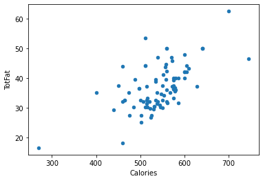

```python
chocolate.plot.scatter(x = "Calories", y = "TotFat")
```